# An overview of plotly’s R API

Carson Sievert

To create a plotly visualization, start with `plot_ly()`.

```r
library(plotly)
plot_ly(economics, x = date, y = unemploy / pop)
```

[interactive chart not shown]

A plotly visualization is composed of one (or more) trace(s), and every trace has a `type` (the default type is ‘scatter’). The arguments/properties that a trace will respect ([documented here](https://plot.ly/r/reference)) depend on it’s type. A scatter trace respects `mode`, which can be any combination of “lines”, “markers”, “text” joined with a “+”:

```r
library(plotly)
plot_ly(economics, x = date, y = unemploy / pop,
        type = "scatter", mode = "markers+lines")
```

[interactive chart not shown]

You can manually add a trace to an existing plot with `add_trace()`. In that case, you’ll want to either `name` your traces, or hide the legend by setting `showlegend = FALSE`

```r
m <- loess(unemploy / pop ~ as.numeric(date), data = economics)
p <- plot_ly(economics, x = date, y = unemploy / pop, name = "raw")
add_trace(p, x = date, y = fitted(m), name = "loess")
```

[interactive chart not shown]

**plotly** was designed with a [pure, predictable, and pipeable interface](https://dl.dropboxusercontent.com/u/41902/pipe-dsls.pdf) in mind, so you can also use the `%>%` operator to create a visualization pipeline:

```r
economics %>%
  plot_ly(x = date, y = unemploy / pop) %>%
  add_trace(x = date, y = fitted(m)) %>%
  layout(showlegend = F)
```

[interactive chart not shown]

Furthermore, `plot_ly()`, `add_trace()`, and `layout()`, all accept a data frame as their first argument and output a data frame. As a result, we can inter-weave data manipulations and visual mappings in a single pipeline.

```r
economics %>%
  transform(rate = unemploy / pop) %>%
  plot_ly(x = date, y = rate) %>%
  subset(rate == max(rate)) %>%
  layout(
    showlegend = F,
    annotations = list(x = date, y = rate, text = "Peak", showarrow = T)
  )
```

[interactive chart not shown]

Although these functions output special “plotly data frames”, `plot_ly()` doesn’t require a data frame for input. This makes chart types that accept a `z` argument especially easy to use if you have a numeric matrix:

```r
s <- plot_ly(z = volcano, type = "surface")
```

If you have [a free plotly account](https://plot.ly/r/getting-started/), `plotly_POST()` makes it easy to host/share any plotly figure (click on the image below to see the interactive version).

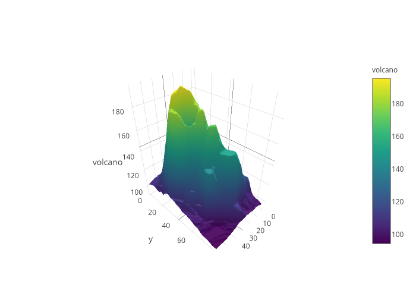

https://plot.ly/~agvd/1794

```r
plotly_POST(s)
```

## Special arguments

The **plotly** function arguments used thus far are documented in [the figure reference](https://plot.ly/r/reference), but there are a handful of additional arguments not described in the reference that make common visualizations a bit easier. These arguments are very much inspired by the semantics of ggplot2’s `qplot()` in the sense that a scales are automatically applied these variables.

### The color argument

#### Qualitative color mappings

If a ordinal variable (aka a non-ordered factor variable) is assigned to color, then a qualitative color palette is used by default.

```r
plot_ly(iris, x = Petal.Length, y = Petal.Width,
        color = Species, mode = "markers")
```

[interactive chart not shown]

If you want to change the default palette, it’s recommended that you provide a http://colorbrewer2.org qualitative pallette name (e.g., “Set1” or “Accent”) to the colors argument.

```r
plot_ly(iris, x = Petal.Length, y = Petal.Width,
        color = Species, colors = "Set1", mode = "markers")
```

[interactive chart not shown]

In this case, the palette consists of 9 colors and the default behavior is to pick colors that are furthest apart (“#E41A1C”, “#FF7F00”, and “#999999”).

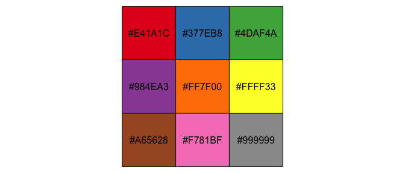

```r
cols <- RColorBrewer::brewer.pal(9, "Set1")
scales::show_col(cols)
```

If you’d like more control over the mapping, you can provide a vector of colors (of appropriate length).

```r
cols <- RColorBrewer::brewer.pal(nlevels(iris$Species), "Set1")
plot_ly(iris, x = Petal.Length, y = Petal.Width,
        color = Species, colors = cols, mode = "markers")
```

[interactive chart not shown]

#### Sequential color mappings

If either a numeric or an ordered factor is mapped to color, `plot_ly()` applies a sequential color scale by default.

```r
plot_ly(iris, x = Petal.Length, y = Petal.Width,
        color = as.ordered(Species), mode = "markers")
```

[interactive chart not shown]

In the case of continuous numeric variables, `plot_ly()` performs a linear mapping between the data and an interpolated color pallette.

```r
plot_ly(iris, x = Petal.Length, y = Petal.Width,
        color = Sepal.Length, mode = "markers")
```

[interactive chart not shown]

The colors argument takes arbitrary color codes of arbitrary length. Here is how we could use it to replicate the default mapping in ggplot2.

```r
plot_ly(iris, x = Petal.Length, y = Petal.Width,
        color = Sepal.Length, colors = c("#132B43", "#56B1F7"),
        mode = "markers")
```

[interactive chart not shown]

#### Diverging color mappings

To obtain a diverging color mapping, just provide a diverging palette to the colors argument.

```r
plot_ly(iris, x = Petal.Length, y = Petal.Width,
        color = Sepal.Length, colors = "PuOr", mode = "markers")
```

[interactive chart not shown]

### The symbol argument

To encode values using symbols, use the symbol argument.

```r
plot_ly(iris, x = Petal.Length, y = Petal.Width,
        symbol = Species, mode = "markers")
```

[interactive chart not shown]

To change the default symbols used, use the symbols argument. All the valid symbol types are listed [here](https://plot.ly/r/reference/#marker).

```r
plot_ly(iris, x = Petal.Length, y = Petal.Width, mode = "markers",
        symbol = Species, symbols = c("cross", "square", "triangle-down"))
```

[interactive chart not shown]